# Работа с временными рядами в tidyverse

Заходякин Г.В.

9 января 2019 г

# Введение

Пакет `forecast` использует временные ряды типа `ts`, а не табличные данные (`tibble` или `data_frame`). Это затрудняет подготовку данных для анализа и использование результатов средствами tidyverse. В настоящее время разработаны пакеты, позволяющие интегрировать пакеты для работы с временными рядами, использующие собственные форматы (`ts`, `zoo`, `xts`) с tidyverse.

С ними можно познакомиться здесь:

- `timetk` - для преобразования временных рядов в таблицы и обратно - https://business-science.github.io/timetk/
- `sweep` - для преобразования моделей временных рядов и прогнозов по ним в таблицы - https://business-science.github.io/sweep/
- `tidyquant` - для работы с финансовыми временными рядами - https://business-science.github.io/tidyquant/
- `tibbletime` - для добавления возможности обработки хронологических данных в табличном формате - https://business-science.github.io/tibbletime/
- `anomalize` - для выявления выбросов и нетипичных наблюдений временных рядов - https://business-science.github.io/anomalize/

В этом блокноте рассмотрено использование пакетов `timetk` и `sweep` для автоматизации некоторых задач прогнозирования:

- построения прогнозов одновременно для множества временных рядов
- применения нескольких моделей к одному временному ряду с целью их сравнения и выбора лучшей модели

Принципы, позволяющие автоматизировать работу с множеством рядов или моделей, рассмотрены в главе [25 Many Models](https://r4ds.had.co.nz/many-models.html) книги R for Data Science. Применение функций `map*()` рассмотрено разделе [21.5 The map functions](https://r4ds.had.co.nz/iteration.html#the-map-functions) этой же книги.

Хорошее объяснение работы со столбцами таблиц, содержащими объекты (**list-columns**) дается также в видео Garret Grolemund [How to Work with List Columns](https://resources.rstudio.com/webinars/how-to-work-with-list-columns-garrett-grolemund), рекомендуем его посмотреть.

Данный блокнот основан на примерах Matt Dancho:

- [Introduction to sweep](https://business-science.github.io/sweep/articles/SW00_Introduction_to_sweep.html)
- [Forecasting Time Series Groups in the tidyverse](https://business-science.github.io/sweep/articles/SW01_Forecasting_Time_Series_Groups.html)
- [Forecasting Using Multiple Models](https://business-science.github.io/sweep/articles/SW02_Forecasting_Multiple_Models.html)

```r
library(tidyverse)
library(forecast)
library(readxl)
library(lubridate) # для работы с датами
library(timetk) # для преобразования таблиц во временные ряды и обратно
library(sweep) # для преобразования результатов моделирования в табличный формат
```

# Принципы работы пакета `sweep`

Пакет `sweep` содержит несколько функций, которые позволяют получить результаты анализа временных рядов и прогнозирования в табличном виде. Среди них:

- функции для преобразования в табличный вид моделей временных рядов и различных характеристик этих моделей: `sw_tidy`, `sw_glance`, `sw_augment`, `sw_tidy_decomp`;
- функции для преобразования в таблицу прогноза, полученного с помощью функции `forecast()`: `sw_sweep`.

Типичный рабочий процесс включает несколько шагов:

1. Загрузка данных и их подготовка к анализу (в табличном формате, средствами `tidyverse`)
2. Преобразование таблицы во временной ряд ts (средствами пакета `timetk`)
3. Анализ и моделирование временного ряда (средствами пакета `forecast`)
4. Преобразование результатов анализа ряда в табличный формат (с помощью `sweep`) для их визуализации
5. Прогнозирование временного ряда (`forecast`)
6. Преобразование прогноза в табличный формат (`sweep`)

Хотя все действия с временным рядом можно проводить и только используя стандартные функции пакета `forecast`, или встроенные в R, интеграция с `tidyverse` полезна тем, что в этой среде удобно проводить работу одновременно с большим количеством объектов (моделей или рядов).

## Загрузка данных

```r
catalog <- read_excel('data/catalog.xlsx') %>%
  mutate(date = as_date(date)) # по умолчанию будет использоваться формат дат,
                               # который не поддерживается ggplot2,
                               # поэтому преобразуем даты к нужному формату

catalog %>% head()
```

```
## # A tibble: 6 x 9
##   date          men  women  jewel  mail  page phone  print service
##   <date>      <dbl>  <dbl>  <dbl> <dbl> <dbl> <dbl>  <dbl>   <dbl>
## 1 1989-01-01 11358. 16579. 10776.  7978    73    34 22294.      20
## 2 1989-02-01 10606. 18236. 10822.  8290    88    29 27426.      20
## 3 1989-03-01 16999. 43394. 22846.  8029    65    24 27979.      26
## 4 1989-04-01  6564. 30908. 11103.  7752    85    20 28950.      22
## 5 1989-05-01  6608. 28702. 16067.  8685    74    17 22642.      21
## 6 1989-06-01  9839  29648. 11061.  7847    87    30 27211.      23
```

Данные представляют собой данные о продажах трех товарных категорий: мужская одежда (`men`), женская одежда (`women`) и украшения (`jewel`). Помимо данных о продажах, доступны также такие факторы, как количество разосланных покупателям каталогов, затратах на рекламу и др., однако они не будут использоваться в этом примере.

В первой части блокнота рассмотрим работу с одномерным временным рядом на примере продаж женской одежды (`women`), а затем покажем, как работать со всеми тремя категориями одновременно.

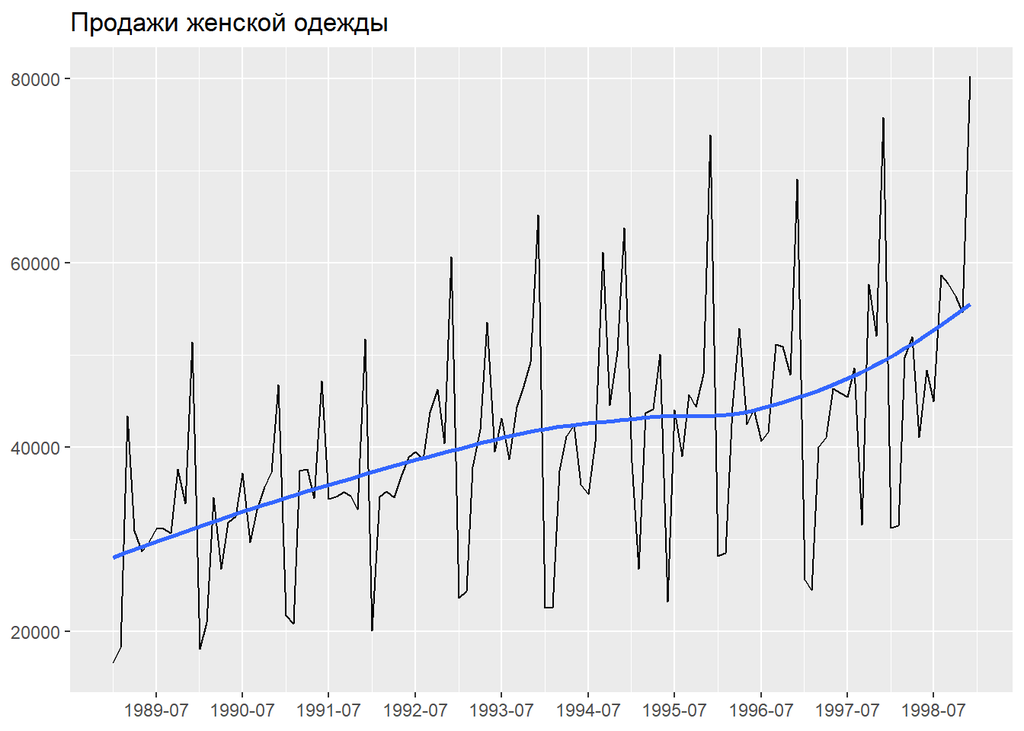

```r
catalog %>%
  ggplot(aes(x = date)) +
    geom_line(aes(y = women)) +
    geom_smooth(aes(y = women), se = F) +
    scale_x_date(date_breaks = "12 month", date_labels = "%Y-%m") +
    labs(x = NULL, y = NULL,
         title = 'Продажи женской одежды')
```

## Получение временного ряда из таблицы

Для анализа и моделирования ряда средствами пакета `forecast` его надо преобразовать в объект типа `ts`. Ранее для этого мы использовали стандартную функцию `ts()`. В этом примере воспользуемся функцией `tk_ts()` пакета `timetk`:

```r
starting_date <- min(catalog$date)
women_ts <- catalog %>%
  select(date, women) %>%
  tk_ts(start =
          c(year(starting_date),month(starting_date)),
        frequency = 12,
        silent = TRUE) # отключаем предупреждение об отброшенном столбце date
```

Функция `tk_ts()` удобнее в использовании с табличными данными, поскольку она автоматически отбрасывает нечисловые столбцы. Функция `ts()` может работать только с числовыми данными, поэтому сначала потребуется удалить из таблицы все нечисловые столбцы вручную.

Кроме того, при использовании `tk_ts()` в объект ts добавляется специальный индекс, который в дальнейшем облегчает работу с датами (timetk index):

```r
has_timetk_idx(women_ts)
```

```
## [1] TRUE
```

## Анализ и моделирование ряда

В этом примере для краткости мы опустим этап декомпозиции и анализа временного ряда и перейдем сразу к моделированию. Используя функцию `forecast::ets()`, получим модель временного ряда с автоматически подобранными параметрами:

```r
m_women <- women_ts %>% ets()
```

Вместо использования стандартной функции `summary` для изучения модели, преобразуем результаты в табличный формат, с которым легко работать в `tidyverse`. С этой целью можно использовать следующие функции пакета `sweep`:

- `sw_tidy()` - параметры модели в виде таблицы;
- `sw_glance()` - показатели качества модели в виде таблицы;
- `sw_augment()` - прогноз, факт и остатки модели на обучающем периоде в виде таблицы;
- `sw_tidy_decomp()` - компоненты временного ряда в виде таблицы;
- `sw_sweep()` - результаты прогнозирования в виде таблицы.

Совместимость функций `sweep` и функций пакета `forecast` приведена в следующей таблице. Более полную версию можно найти [здесь](https://business-science.github.io/sweep/articles/SW00_Introduction_to_sweep.html).

| Object | sw_tidy() | sw_glance() | sw_augment() | sw_tidy_decomp() | sw_sweep() |
| --- | --- | --- | --- | --- | --- |
| Arima | X | X | X |  |  |
| ets | X | X | X | X |  |
| stl |  |  |  | X |  |
| HoltWinters | X | X | X | X |  |
| decompose |  |  |  | X |  |
| forecast |  |  |  |  | X |

Параметры модели:

```r
m_women %>% sw_tidy()
```

```
## # A tibble: 16 x 2
##    term      estimate
##    <chr>        <dbl>
##  1 alpha     0.00114
##  2 beta      0.00114
##  3 gamma     0.000101
##  4 l     31070.
##  5 b       204.
##  6 s0        1.55
##  7 s1        1.07
##  8 s2        1.10
##  9 s3        1.07
## 10 s4        0.970
## 11 s5        0.970
## 12 s6        0.973
## 13 s7        1.01
## 14 s8        0.998
## 15 s9        1.03
## 16 s10       0.645
```

Выводятся подобранные `ets()` параметры модели - константы сглаживания и начальные оценки уровня, тренда и сезонных коэффициентов.

Ошибки модели на обучающем множестве:

```r
m_women %>% sw_glance()
```

```
## # A tibble: 1 x 12
##   model.desc sigma logLik   AIC   BIC    ME  RMSE   MAE   MPE  MAPE  MASE
##   <chr>      <dbl>  <dbl> <dbl> <dbl> <dbl> <dbl> <dbl> <dbl> <dbl> <dbl>
## 1 ETS(M,A,M) 0.139 -1312. 2659. 2706. -624. 5059. 3479. -3.41  9.33 0.616
## # ... with 1 more variable: ACF1 <dbl>
```

Таблица с фактическим и прогнозным значениями в историческом периоде, остатки модели:

```r
aug_m_women <- m_women %>%
  sw_augment(rename_index = 'date',
             timetk_idx = TRUE) # Эти аргументы добавлены для получения
                                # даты в формате, который напрямую
                                # поддерживается gglpot2

aug_m_women %>% head()
```

```
## # A tibble: 6 x 4
##   date       .actual .fitted  .resid
##   <date>       <dbl>   <dbl>   <dbl>
## 1 1989-01-01  16579.  19459. -0.148
## 2 1989-02-01  18236.  20297. -0.102
## 3 1989-03-01  43394.  32546.  0.333
## 4 1989-04-01  30908.  31822. -0.0287
## 5 1989-05-01  28702.  32257. -0.110
## 6 1989-06-01  29648.  31405. -0.0560
```

На этапе оценки адекватности модели визуализация остатков используется для того, чтобы выяснить, нет ли в поведении остатков каких-то закономерностей? Если они имеются, значит модель не учитывает их, содержит систематическую ошибку. Ее можно улучшить, если удастся включить эти закономерности в модель.

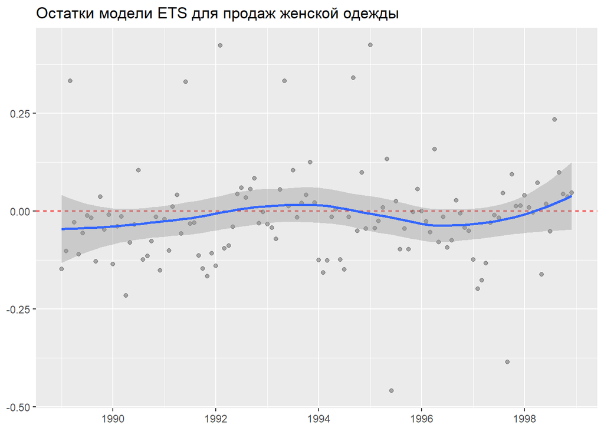

```r
aug_m_women %>%
  ggplot(aes(x = date, y = .resid)) +
  geom_hline(yintercept = 0, color = "red", linetype = 'dashed') +
  geom_point(alpha = 0.3) +
  geom_smooth(method = loess) +
  scale_x_date() +
  labs(x = NULL, y = NULL,
       title = "Остатки модели ETS для продаж женской одежды")
```

Наблюдаются небольшие систематические отклонения средних остатков от нуля. Возможно, они вызваны тем, что константы сглаживания для модели выбраны слишком маленькими. Этот вопрос мы исследуем в последнем разделе этого блокнота.

Модели экспоненциального сглаживания основаны на выделении компонентов временного ряда - среднего уровня, тренда и сезонности. Поэтому данные компоненты можно извлечь из модели.

```r
decomp_m_women <- m_women %>%
  sw_tidy_decomp(rename_index = 'date', timetk_idx = TRUE)

decomp_m_women %>% head()
```

```
## # A tibble: 6 x 5
##   date       observed  level slope season
##   <date>        <dbl>  <dbl> <dbl>  <dbl>
## 1 1989-01-01   16579. 31268.  198.  0.622
## 2 1989-02-01   18236. 31463.  195.  0.645
## 3 1989-03-01   43394. 31670.  207.  1.03
## 4 1989-04-01   30908. 31875.  206.  0.998
## 5 1989-05-01   28702. 32077.  202.  1.01
## 6 1989-06-01   29648. 32276.  200.  0.973
```

Поскольку компоненты ряда имеют разный масштаб, их удобнее сравнивать на отдельных графиках. Их можно получить с помощью разделения на панели, однако потребуется преобразовать таблицу в “длинный” формат, используя функцию `tidyr::gather()`.

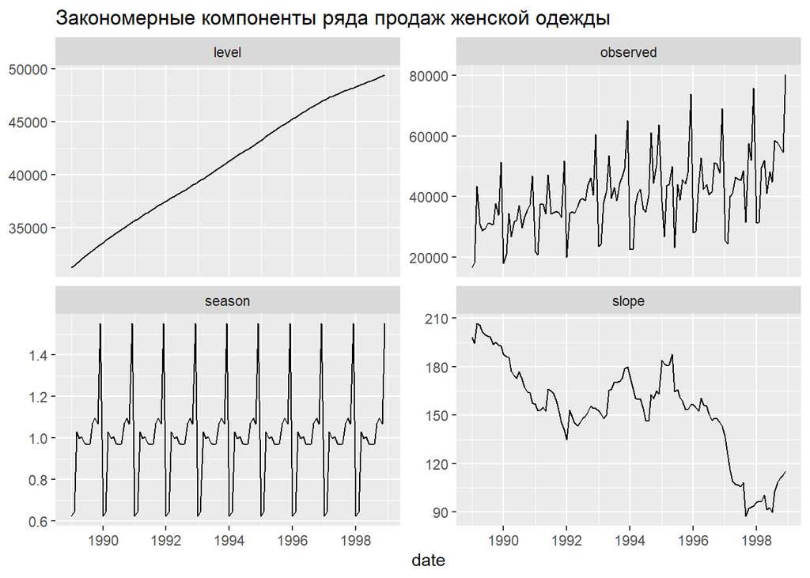

```r
decomp_m_women %>%
  gather(key = key, value = value, -date) %>%
  ggplot(aes(x = date, y = value)) +
  geom_line() +
  facet_wrap(~ key, scales = "free_y") +
  scale_x_date() +
  labs(X = NULL, y = NULL,
       title = "Закономерные компоненты ряда продаж женской одежды")
```

## Получение прогноза в табличном виде

Прогнозирование выполняется стандартным образом - с помощью функции `forecast()`. Для преобразования прогноза в табличный формат, можно воспользоваться функцией `sw_sweep()`.

```r
f_women <- m_women %>% forecast(h = 12)

f_women %>%
  sw_sweep(rename_index = 'date', timetk_idx = TRUE) %>%
  tail(n = 14)
```

```
## # A tibble: 14 x 7
##    date       key       women  lo.80  lo.95  hi.80   hi.95
##    <date>     <chr>     <dbl>  <dbl>  <dbl>  <dbl>   <dbl>
##  1 1998-11-01 actual   54617.    NA     NA     NA      NA
##  2 1998-12-01 actual   80246.    NA     NA     NA      NA
##  3 1999-01-01 forecast 30824. 25349. 22450. 36300.  39198.
##  4 1999-02-01 forecast 32029. 26339. 23328. 37718.  40730.
##  5 1999-03-01 forecast 51166. 42077. 37266. 60255.  65067.
##  6 1999-04-01 forecast 49800. 40954. 36271. 58647.  63330.
##  7 1999-05-01 forecast 50276. 41345. 36617. 59207.  63935.
##  8 1999-06-01 forecast 48760. 40098. 35512. 57422.  62007.
##  9 1999-07-01 forecast 48709. 40056. 35475. 57362.  61943.
## 10 1999-08-01 forecast 48855. 40176. 35581. 57535.  62130.
## 11 1999-09-01 forecast 54056. 44452. 39368. 63661.  68745.
## 12 1999-10-01 forecast 55505. 45643. 40422. 65368.  70588.
## 13 1999-11-01 forecast 54172. 44546. 39450. 63798.  68894.
## 14 1999-12-01 forecast 78794. 64792. 57379. 92797. 100209.
```

По умолчанию `forecast()` вычисляет 80 и 95% доверительные интервалы для прогноза. При необходимости их можно поменять (см `?forecast`).

При необходимости, можно вывести и подогнанные значения в историческом периоде, добавив аргумент `fitted = TRUE` для функции `sw_sweep()`. Здесь мы не будем этого делать, чтобы не загромождать график.

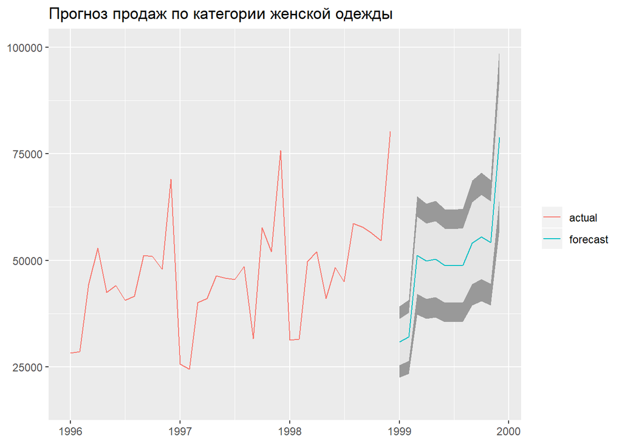

```r
f_women %>%
  sw_sweep(rename_index = 'date', timetk_idx = TRUE) %>%
  ggplot(aes(x = date, y = women)) +
  geom_ribbon(aes(ymin = lo.95, ymax = hi.95), fill = "gray60") +
  geom_ribbon(aes(ymin = lo.80, ymax = hi.80), fill = "gray90") +
  geom_line(aes(color = key)) +
  scale_x_date(date_labels = "%Y", date_breaks = "1 year",
               limits = c(ymd("1996-01-01"), NA)) +
  labs(x = NULL, y = NULL,
       title = "Прогноз продаж по категории женской одежды",
       color = NULL)
```

# Прогнозирование для множества временных рядов

Интеграция функций для моделирования временных рядов с `tidyverse` полезна тем, что позволяет задействовать функции для групповой обработки данных, которые доступны в `tidyverse`. В этом разделе рассмотрим пример прогнозирования для множества временных рядов.

## Шаг 1. Подготовка таблицы данных

Оставим из исходного набора данных только столбцы с датой и объемами продаж по трем товарным категориям. Также для работы необходимо преобразовать таблицу в “длинный” формат.

```r
catalog3 <-
  catalog %>%
  select(date:jewel) %>%
  gather(key=item, value=sales, -date)

catalog3 %>% head()
```

```
## # A tibble: 6 x 3
##   date       item   sales
##   <date>     <chr>  <dbl>
## 1 1989-01-01 men   11358.
## 2 1989-02-01 men   10606.
## 3 1989-03-01 men   16999.
## 4 1989-04-01 men    6564.
## 5 1989-05-01 men    6608.
## 6 1989-06-01 men    9839
```

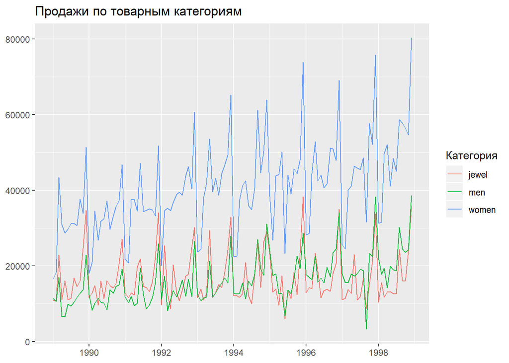

```r
catalog3 %>%
  ggplot(aes(date, sales, color = item)) +
  geom_line() +
  labs(x = NULL, y = NULL, color = "Категория",
       title = "Продажи по товарным категориям")
```

Групповое прогнозирование основано на применении групповой обработки к таблице, в которой строками являются товарные категории, а данные о продажах по категории добавлены как вложенные (**nested**) таблицы. Такую таблицу можно получить при помощи функции `tidyr::nest()`

```r
catalog3_nested <-
  catalog3 %>%
  group_by(item) %>%
  nest()

catalog3_nested
```

```
## # A tibble: 3 x 2
##   item  data
##   <chr> <list>
## 1 men   <tibble [120 x 2]>
## 2 women <tibble [120 x 2]>
## 3 jewel <tibble [120 x 2]>
```

Каждая строка соответствует одной товарной категории. В столбце `data` для каждой категории вложена таблица с историей продаж.

```r
glimpse(catalog3_nested)
```

```
## Observations: 3
## Variables: 2
## $ item <chr> "men", "women", "jewel"
## $ data <list> [<tbl_df[120 x 2]>, <tbl_df[120 x 2]>, <tbl_df[120 x 2]>]
```

```r
catalog3_nested$data[[1]] %>% head()
```

```
## # A tibble: 6 x 2
##   date        sales
##   <date>      <dbl>
## 1 1989-01-01 11358.
## 2 1989-02-01 10606.
## 3 1989-03-01 16999.
## 4 1989-04-01  6564.
## 5 1989-05-01  6608.
## 6 1989-06-01  9839
```

Напомним, что принципы, которые мы здесь используем, подробно рассмотрены в главе [25 Many Models](https://r4ds.had.co.nz/many-models.html) книги R for Data Science.

## Шаг 2. Преобразование таблицы данных в ряд ts.

Поскольку функции для прогнозирования работают только с рядами в формате `ts`, необходимо преобразовать все вложенные таблицы к этому формату, используя функцию `tk_ts()`, как было показано ранее.

Данную функцию надо применить к каждой ячейке в столбце `data`. Этого можно добиться, используя функции `tidyr::mutate()` и `purrr:map()`.

```r
# Вспомогательная функция для создания
# временного ряда из таблицы данных
make_ts <- function(tbl) {
  starting_date <- min(tbl$date)
  series <- tk_ts(tbl,
                  start = c(year(starting_date),
                            month(starting_date)),
                  frequency = 12,
                  silent = TRUE)
}

# Применяем нашу функцию к таблице данных
catalog3_nested_ts <-
  catalog3_nested %>%
  mutate(data_ts = map(data, make_ts))

catalog3_nested_ts %>% head()
```

```
## # A tibble: 3 x 3
##   item  data               data_ts
##   <chr> <list>             <list>
## 1 men   <tibble [120 x 2]> <ts>
## 2 women <tibble [120 x 2]> <ts>
## 3 jewel <tibble [120 x 2]> <ts>
```

Код можно упростить, применив сразу функцию `tk_ts()`, но это не будет работать правильно, если временные ряды отличаются по начальной дате.

Функция `map()` позволяет применить функцию к списку объектов и выдает список с результатами этого применения. Мы можем применить функцию map к столбцу таблицы, который также может рассматриваться как список.

Применение функций семейства `map*()` рассмотрено разделе [21.5 The map functions](https://r4ds.had.co.nz/iteration.html#the-map-functions) книги R for Data Science.

## Шаг 3. Построение моделей для всех рядов в таблице

Дальнейшая работа повторяет процесс, описанный в первом разделе блокнота. Однако теперь функции пакета `sweep` будут применяться не к одному ряду, а сразу ко всей таблице, с использованием функции `map()`.

```r
catalog3_nested_fit <-
  catalog3_nested_ts %>%
  mutate(fit = map(data_ts, ets))

catalog3_nested_fit
```

```
## # A tibble: 3 x 4
##   item  data               data_ts fit
##   <chr> <list>             <list>  <list>
## 1 men   <tibble [120 x 2]> <ts>    <ets>
## 2 women <tibble [120 x 2]> <ts>    <ets>
## 3 jewel <tibble [120 x 2]> <ts>    <ets>
```

Используя функцию map() и функции из пакета `sweep`, можно получить в табличном виде параметры моделей или оценку их качества.

Получим таблицу для сравнения параметров построенных моделей, используя `sw_tidy()`.

```r
catalog3_nested_fit %>%
  mutate(coefs = map(fit, sw_tidy))
```

```
## # A tibble: 3 x 5
##   item  data               data_ts fit    coefs
##   <chr> <list>             <list>  <list> <list>
## 1 men   <tibble [120 x 2]> <ts>    <ets>  <tibble [16 x 2]>
## 2 women <tibble [120 x 2]> <ts>    <ets>  <tibble [16 x 2]>
## 3 jewel <tibble [120 x 2]> <ts>    <ets>  <tibble [14 x 2]>
```

Поскольку после применения `map()` результаты получаются в виде вложенной в ячейку таблицы, необходимо “распаковать” эту вложенную таблицу и объединить все результаты в одну общеую таблицу. Этого можно добиться с помощью функции `unnest()`.

```r
catalog3_nested_fit %>%
  mutate(coefs = map(fit, sw_tidy)) %>%
  unnest(coefs) %>%
  spread(key = item, value = estimate) # разворачивание товарных категорий в столбцы
```

```
## # A tibble: 16 x 4
##    term         jewel          men        women
##    <chr>        <dbl>        <dbl>        <dbl>
##  1 alpha     0.00102      0.0332       0.00114
##  2 b        NA           64.4        204.
##  3 beta     NA            0.00162      0.00114
##  4 gamma     0.000101     0.000100     0.000101
##  5 l     16608.       11600.       31070.
##  6 s0    15772.           1.71         1.55
##  7 s1     6400.           1.05         1.07
##  8 s10   -2228.           0.864        0.645
##  9 s2     -718.           1.07         1.10
## 10 s3     -758.           1.01         1.07
## 11 s4    -1621.           0.979        0.970
## 12 s5    -3930.           0.826        0.970
## 13 s6    -4343.           0.908        0.973
## 14 s7     3039.           0.885        1.01
## 15 s8    -4076.           0.829        0.998
## 16 s9    -3189.           0.905        1.03
```

Используя функцию `sw_glance()`, сравним ошибки моделей для разных товарных групп:

```r
catalog3_nested_fit %>%
  mutate(performance = map(fit, sw_glance)) %>%
  unnest(performance, .drop = TRUE) %>%
  # распаковать столбец с ошибками, удалив остальные столбцы
  select(item, model.desc, MPE, MAPE, MASE)
```

```
## # A tibble: 3 x 5
##   item  model.desc   MPE  MAPE  MASE
##   <chr> <chr>      <dbl> <dbl> <dbl>
## 1 men   ETS(M,A,M) -5.90 18.3  0.607
## 2 women ETS(M,A,M) -3.41  9.33 0.616
## 3 jewel ETS(A,N,A) -3.58 14.1  0.647
```

Используя функцию `sw_augment()`, получим таблицу для сравнения факта с прогнозом, содержащую также остатки.

```r
catalog3_augment <-
  catalog3_nested_fit %>%
  mutate(augment = map(fit, sw_augment,
                       timetk_idx = TRUE,
                       rename_index = "date")) %>%
  unnest(augment, .drop = TRUE)

catalog3_augment %>% head()
```

```
## # A tibble: 6 x 5
##   item  date       .actual .fitted  .resid
##   <chr> <date>       <dbl>   <dbl>   <dbl>
## 1 men   1989-01-01  11358.  11218.  0.0125
## 2 men   1989-02-01  10606.  10140.  0.0460
## 3 men   1989-03-01  16999.  10689.  0.590
## 4 men   1989-04-01   6564.  10058. -0.347
## 5 men   1989-05-01   6608.  10669. -0.381
## 6 men   1989-06-01   9839   10860. -0.0940
```

Графики остатков моделей

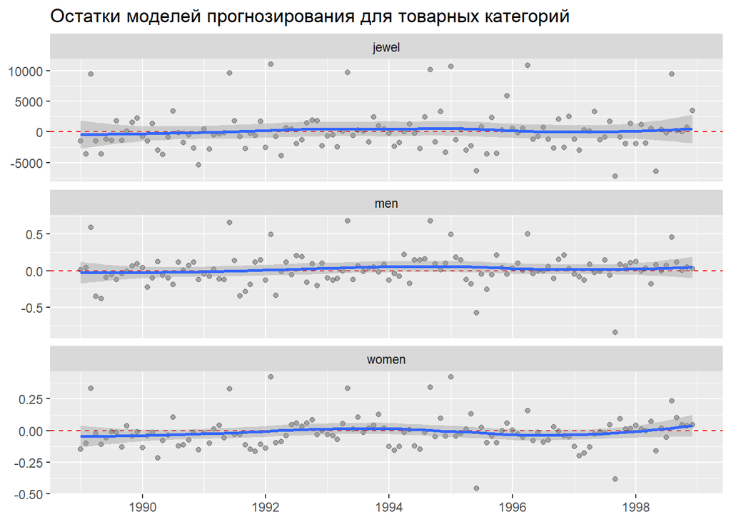

```r
catalog3_augment %>%
  ggplot(aes(x = date, y = .resid)) +
  geom_hline(yintercept = 0, color = 'red', linetype = 'dashed') +
  geom_point(alpha = 0.3) +
  geom_smooth(method = 'loess') +
  facet_wrap(~ item, scale = 'free_y', ncol = 1) +
  labs(x = NULL, y = NULL,
       title = "Остатки моделей прогнозирования для товарных категорий")
```

**Примечание** модель для украшений - аддитивная, а модели для мужской и женской одежды - мультипликативные, поэтому масштаб остатков сильно отличается.

## Шаг 4. Прогнозирование для всех рядов в таблице

Для получения прогноза, к столбцу с моделями можно применить функцию `forecast()`. Параметры для применяемой функции перечисляются через запятую после ее имени. В данном случае зададим только горизонт прогнозирования.

```r
catalog3_forecast <-
  catalog3_nested_fit %>%
  mutate(forecast = map(fit, forecast, h = 24))

catalog3_forecast
```

```
## # A tibble: 3 x 5
##   item  data               data_ts fit    forecast
##   <chr> <list>             <list>  <list> <list>
## 1 men   <tibble [120 x 2]> <ts>    <ets>  <forecast>
## 2 women <tibble [120 x 2]> <ts>    <ets>  <forecast>
## 3 jewel <tibble [120 x 2]> <ts>    <ets>  <forecast>
```

Чтобы извлечь значения прогноза в табличном виде, необходимо применить к столбцу `forecast` функцию `sw_sweep()`.

```r
catalog3_forecast_tidy <-
  catalog3_forecast %>%
  mutate(tidy_forecast = map(forecast, sw_sweep,
                             fitted = FALSE,
                             timetk_idx = TRUE,
                             rename_index = 'date')) %>%
  unnest(tidy_forecast, .drop = TRUE)

catalog3_forecast_tidy %>% tail()
```

```
## # A tibble: 6 x 8
##   item  date       key       sales  lo.80  lo.95  hi.80  hi.95
##   <chr> <date>     <chr>     <dbl>  <dbl>  <dbl>  <dbl>  <dbl>
## 1 jewel 2000-07-01 forecast 12693.  8083.  5643. 17304. 19744.
## 2 jewel 2000-08-01 forecast 15003. 10393.  7953. 19613. 22054.
## 3 jewel 2000-09-01 forecast 15865. 11255.  8815. 20475. 22916.
## 4 jewel 2000-10-01 forecast 15905. 11295.  8855. 20515. 22956.
## 5 jewel 2000-11-01 forecast 23024. 18414. 15973. 27634. 30074.
## 6 jewel 2000-12-01 forecast 32396. 27786. 25346. 37006. 39446.
```

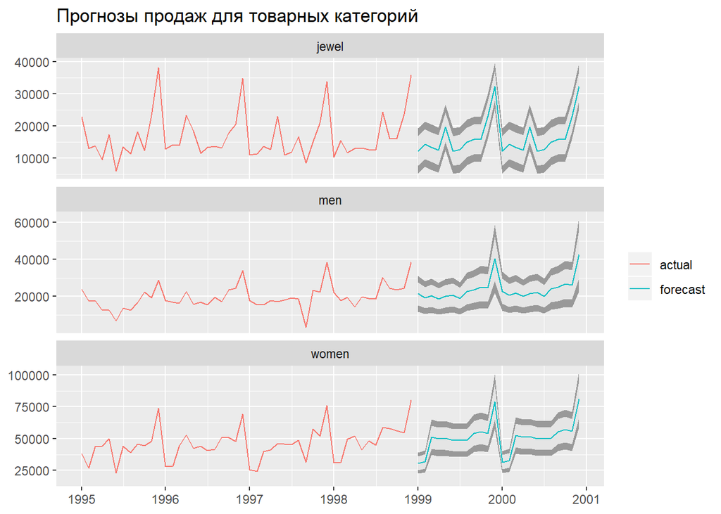

```r
catalog3_forecast_tidy %>%
  ggplot(aes(x = date, y = sales)) +
  geom_ribbon(aes(ymin = lo.95, ymax = hi.95), fill = "gray60") +
  geom_ribbon(aes(ymin = lo.80, ymax = hi.80), fill = "gray90") +
  geom_line(aes(color = key)) +
  scale_x_date(date_labels = "%Y", date_breaks = "1 year",
               limits = c(ymd("1995-01-01"), NA)) +
  facet_wrap(~ item, scales = "free_y", ncol = 1) +
  labs(x = NULL, y = NULL, color = NULL,
       title = "Прогнозы продаж для товарных категорий")
```

# Сравнение эффективности нескольких методов прогнозирования

Еще один распространенный случай - применение нескольких моделей прогнозирования к одному ряду для сравнения их эффективности.

Вернемся к ряду продаж категории женской одежды (`women_ts`).

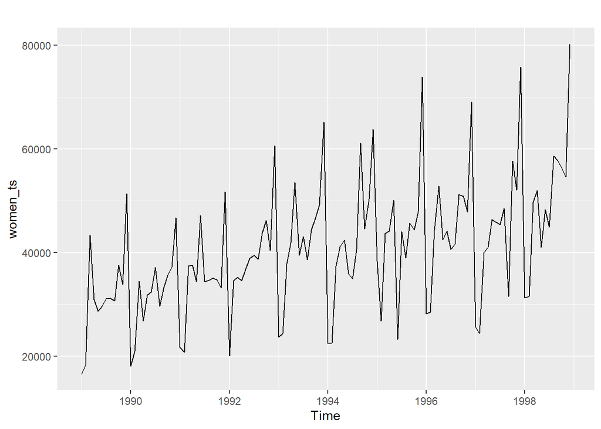

```r
autoplot(women_ts)
```

В первой части этого блокнота использовался автовыбор для прогноза. Была выбрана мультипликативная модель с линейным трендом.

```r
m_women %>% sw_glance() %>% select(model.desc, MAPE, MASE)
```

```
## # A tibble: 1 x 3
##   model.desc  MAPE  MASE
##   <chr>      <dbl> <dbl>
## 1 ETS(M,A,M)  9.33 0.616
```

Константы сглаживания были автоматически выбраны близкими к нулю:

```r
m_women %>% sw_tidy() %>% filter(term %in% c('alpha', 'beta', 'gamma'))
```

```
## # A tibble: 3 x 2
##   term  estimate
##   <chr>    <dbl>
## 1 alpha 0.00114
## 2 beta  0.00114
## 3 gamma 0.000101
```

Попробуем сравнить несколько вариантов ETS-модели с разными константами, а также модель с затухающим трендом.

Для этого можно воспользоватся функцией `purrr::invoke_map()`, которая позволяет выполнить сразу несколько функций, перечисленных в строках таблицы.

Создадим таблицу, в которой в столбце `f` будет содержаться имя функции, а столбце `params` - список необходимых параметров для этой функции. В столбце `lab` содержится метка, которая будет использоваться как подпись для этой модели в таблицах и на графиках.

```r
models <- tribble(
  ~lab,         ~f,     ~params,
  "ets auto",   "ets", list(y = women_ts),
  "ets 0.05",   "ets",  list(y = women_ts, alpha = 0.05, beta = 0.05, gamma = 0.05),
  "ets 0.1",    "ets",  list(y = women_ts, alpha = 0.1, beta = 0.1, gamma = 0.1),
  "ets damped", "ets",  list(y = women_ts, damped = TRUE),
)

models
```

```
## # A tibble: 4 x 3
##   lab        f     params
##   <chr>      <chr> <list>
## 1 ets auto   ets   <named list [1]>
## 2 ets 0.05   ets   <named list [4]>
## 3 ets 0.1    ets   <named list [4]>
## 4 ets damped ets   <named list [2]>
```

Применим функцию `invoke_map()`, чтобы построить модели, указанные в таблице

```r
models_fit <-
  models %>%
  mutate(fit = invoke_map(f, params))

models_fit
```

```
## # A tibble: 4 x 4
##   lab        f     params           fit
##   <chr>      <chr> <list>           <list>
## 1 ets auto   ets   <named list [1]> <ets>
## 2 ets 0.05   ets   <named list [4]> <ets>
## 3 ets 0.1    ets   <named list [4]> <ets>
## 4 ets damped ets   <named list [2]> <ets>
```

Сравним модели по показателям ошибки:

```r
models_perf <-
  models_fit %>%
    mutate(tidy = map(fit, sw_glance)) %>%
    unnest(tidy)

models_perf %>%
  select(lab, MAPE, MASE)
```

```
## # A tibble: 4 x 3
##   lab         MAPE  MASE
##   <chr>      <dbl> <dbl>
## 1 ets auto    9.33 0.616
## 2 ets 0.05    9.75 0.659
## 3 ets 0.1     9.75 0.684
## 4 ets damped  9.32 0.638
```

В данном случае автоматически построенная модель дает наименьшую ошибку MASE, а по MAPE лучшая модель - с затухающим трендом. Однако отличие только в сотых долях, поэтому его можно считать незначимым.

Сравним графики остатков модели:

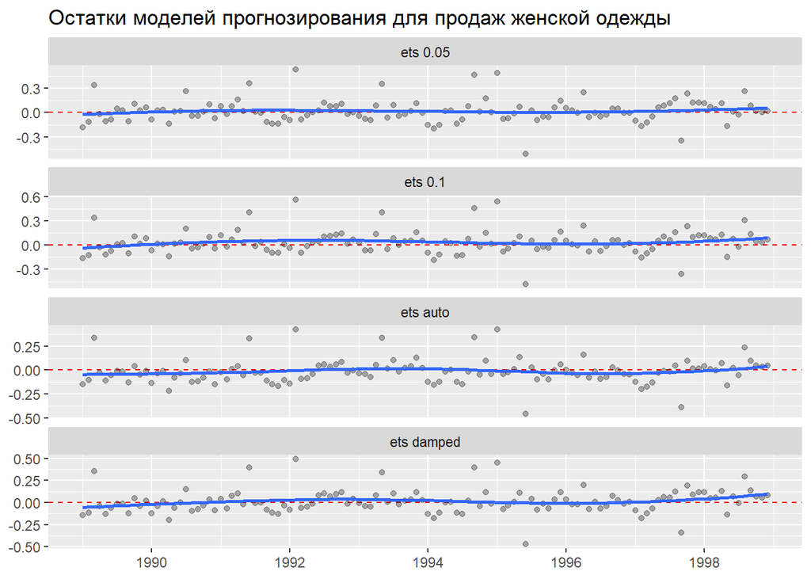

```r
models_fit %>%
  mutate(tidy = map(fit, sw_augment,
                    timetk_idx = TRUE,
                    rename_index = "date")) %>%
  unnest(tidy) %>%
  ggplot(aes(x = date, y = .resid)) +
  geom_hline(yintercept = 0, color = 'red', linetype = 'dashed') +
  geom_point(alpha = 0.3) +
  geom_smooth(method = 'loess', se = F) +
  facet_wrap(~ lab, scale = 'free_y', ncol = 1) +
  labs(x = NULL, y = NULL,
       title = "Остатки моделей прогнозирования для продаж женской одежды")
```

Сравним прогнозы по разным моделям

```r
models_forecast <-
  models_fit %>%
  mutate(fcast = map(fit, forecast, h = 24)) %>%
  mutate(tidy = map(fcast, sw_sweep, timetk_idx = TRUE,
                    rename_index = "date")) %>%
  unnest(tidy)

models_forecast %>% tail()
```

```
## # A tibble: 6 x 9
##   lab        f     date       key       women  lo.80  lo.95  hi.80   hi.95
##   <chr>      <chr> <date>     <chr>     <dbl>  <dbl>  <dbl>  <dbl>   <dbl>
## 1 ets damped ets   2000-07-01 forecast 49945. 39942. 34647. 59947.  65243.
## 2 ets damped ets   2000-08-01 forecast 49951. 39899. 34578. 60003.  65325.
## 3 ets damped ets   2000-09-01 forecast 54920. 43814. 37935. 66026.  71906.
## 4 ets damped ets   2000-10-01 forecast 56641. 45130. 39036. 68152.  74246.
## 5 ets damped ets   2000-11-01 forecast 55373. 44062. 38075. 66684.  72671.
## 6 ets damped ets   2000-12-01 forecast 78558. 62429. 53890. 94688. 103226.
```

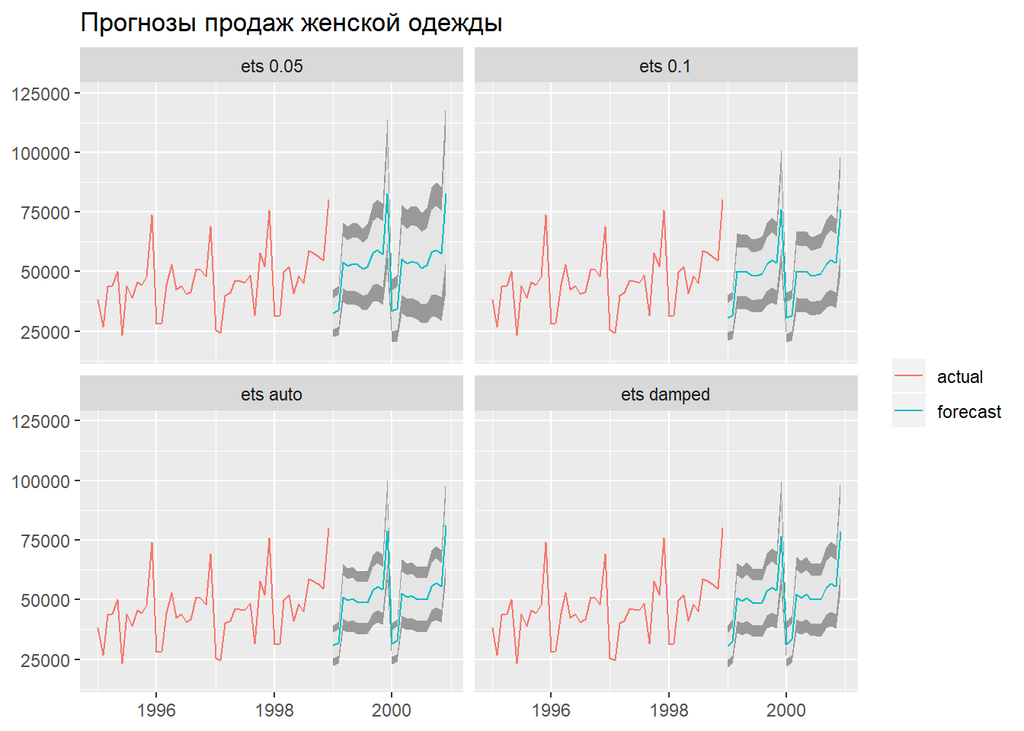

```r
models_forecast %>%
  ggplot(aes(x = date, y = women)) +
    geom_ribbon(aes(ymin = lo.95, ymax = hi.95), fill = "gray60") +
    geom_ribbon(aes(ymin = lo.80, ymax = hi.80), fill = "gray90") +
    geom_line(aes(color = key)) +
    scale_x_date(limits = c(ymd("1995-01-01"), NA)) +
    facet_wrap(~lab, ncol = 2) +
    labs(x = NULL, y = NULL, color = NULL,
         title = "Прогнозы продаж женской одежды")
```

В данном случае автоматически построенная модель показала наилучший результат по ошибке на обучающем множестве. Все модели несущественно отличаются друг от друга.

Если необходимо автоматически выбрать лучшую модель из построенных, это легко сделать сортировкой таблицы с моделями на основе одного из показателей ошибки.

```r
best_model <-
  models_perf %>%
  top_n(n = 1, wt = desc(MASE)) # top_n сортирует по убыванию показателя,
                                # поэтому для выбора модели с наименьшей
                                # ошибкой,необходимо добавить desc(),
                                # чтобы обратить порядок сортировки
best_model %>% select(lab, MASE, fit)
```

```
## # A tibble: 1 x 3
##   lab       MASE fit
##   <chr>    <dbl> <list>
## 1 ets auto 0.616 <ets>
```

Затем можно получить прогноз по лучшей модели обычным образом

```r
best_model %>%
  mutate(fcast = map(fit, forecast, h = 24)) %>%
  mutate(tidy = map(fcast, sw_sweep,
                    timetk_idx = TRUE,
                    rename_index = "date")) %>%
  unnest(tidy, .drop = TRUE) %>%
  select(lab, date:women) %>%
  tail(12)
```

```
## # A tibble: 12 x 4
##    lab      date       key       women
##    <chr>    <date>     <chr>     <dbl>
##  1 ets auto 2000-01-01 forecast 31688.
##  2 ets auto 2000-02-01 forecast 32924.
##  3 ets auto 2000-03-01 forecast 52592.
##  4 ets auto 2000-04-01 forecast 51185.
##  5 ets auto 2000-05-01 forecast 51671.
##  6 ets auto 2000-06-01 forecast 50109.
##  7 ets auto 2000-07-01 forecast 50054.
##  8 ets auto 2000-08-01 forecast 50201.
##  9 ets auto 2000-09-01 forecast 55543.
## 10 ets auto 2000-10-01 forecast 57028.
## 11 ets auto 2000-11-01 forecast 55655.
## 12 ets auto 2000-12-01 forecast 80946.
```